# Annotating Variants Near GREB1L

Eric C. Anderson

Last Updated: 2020-05-14

# Packages and paths

```r
library(tidyverse)
library(vcfR)
```

# Build a SNPeff database

As instructed in the README file, be sure you have downloaded Chinook Otsh_v1.0 genome and the gff files and have put the (or symlinked them) in the `genome` directory.

Also, ensure that you have installed `snpEff` as described in the README.

Building the data base involves setting some symlinks within the snpEff directory and running it:

```bash
cd snpEff_v4_3t_core/snpEff/
mkdir -p data/Otsh_v1.0
cd data/Otsh_v1.0/

# get rid of these if the symlinks already exist from a previous run
rm -f genes.gff.gz
rm -f sequences.fa
# here we symlink sequences.fa to the genome and genes.gff.gz to the gff file.
ln -s ../../../../genome/GCF_002872995.1_Otsh_v1.0_genomic.gff.gz genes.gff.gz
ln -s ../../../../genome/Otsh_v1.0_genomic.fna sequences.fa
```

And then adding some lines to the config file:

```bash
# only to this if the lines have not already been added
# (i.e., if this has alread been run)
if grep -q Otsh_v1.0 snpEff_v4_3t_core/snpEff/snpEff.config; then
    echo "Otsh_v1.0 already added to config file"
else
    echo "Adding Otsh_v1.0 to config file"

    echo "
# Chinook salmon genome, Otsh_v1.0
Otsh_v1.0.genome : Oncorhynchus_tshawytscha_Otsh_V1.0
" >> snpEff_v4_3t_core/snpEff/snpEff.config
fi
```

```
## Otsh_v1.0 already added to config file
```

Now, run it. This takes about 5 minutes.

```bash
cd snpEff_v4_3t_core/snpEff
java -jar snpEff.jar build -gff3 -v Otsh_v1.0 > snpEff_stdout.log 2> snpEff_stderr.log
```

# Running SNPeff

Having created a SNPeff data base from the Otshv1.0 genome and gff files using the standard procedures we should be able to annotate our little 5.16 Mb segment of DNA pretty quickly.

```bash
DIR=$(pwd)

mkdir -p intermediates/005

cd snpEff_v4_3t_core/snpEff

rm -f $DIR/intermediates/005/greb1l-5Mb-snpEff.vcf
rm -f $DIR/intermediates/005/greb1l-5Mb-snpEff.vcf.gz

java -jar snpEff.jar ann Otsh_v1.0 $DIR/data/greb1l-ish-region.vcf.gz > $DIR/intermediates/005/greb1l-5Mb-snpEff.vcf

# after that, bgzip it and index it
cd $DIR/intermediates/005
bgzip greb1l-5Mb-snpEff.vcf
bcftools index -t greb1l-5Mb-snpEff.vcf.gz
```

Now that those are there, I will be able to use them later, attaching them to the imputed variant data and computing some things. To facilitate that, let’s read it into R and clean it up and resave.

# Read results into R and save in outputs

```r
annoV <- read.vcfR("intermediates/005/greb1l-5Mb-snpEff.vcf.gz")
```

[output not shown]

[output cut: 27 more lines]

[output not shown]

```r
TT <- vcfR2tidy(annoV, info_only = TRUE)
```

# Have a look at some possible effect variants

Now, let’s break out the first three columns of the snpEff annotation.

```r
# there are warnings here because we are just grabbing the first three
# columns of many with separate()
TTS <- TT$fix %>%
  separate(ANN, into = c("snp_eff_var", "snp_eff_what", "snp_eff_effect"), remove = FALSE, sep = "\\|")
```

Count up what we see for effects:

```r
TTS %>%
  count(snp_eff_effect, snp_eff_what)
```

| snp_eff_effect | snp_eff_what | n |
| --- | --- | --- |
| HIGH | frameshift_variant | 41 |
| HIGH | frameshift_variant&splice_acceptor_variant&splice_region_variant&intron_variant | 1 |
| HIGH | frameshift_variant&splice_region_variant | 4 |
| HIGH | frameshift_variant&start_lost | 2 |
| HIGH | frameshift_variant&stop_lost | 1 |
| HIGH | splice_acceptor_variant&intron_variant | 7 |
| HIGH | splice_acceptor_variant&splice_region_variant&intron_variant&non_coding_transcript_exon_variant | 1 |
| HIGH | splice_donor_variant&intron_variant | 5 |
| HIGH | start_lost&conservative_inframe_insertion | 1 |
| HIGH | stop_gained | 3 |

[output cut: 21 more lines]

Let’s go ahead and save that.

```r
dir.create("outputs/005", recursive = TRUE, showWarnings = FALSE)
write_rds(TTS, path = "outputs/005/variants-and-annos-5.16.rds", compress = "xz")
```

We will focus on what we find from 12.1 to 12.6 here, as that encompasses GREB1L and ROCK1 and is what we will show for the “moderate zoom” raster

```r
FocReg <- TTS %>%
  filter(POS > 12.1e6 & POS < 12.6e6)

# summarize:
FocReg %>%
  count(snp_eff_effect)
```

| snp_eff_effect | n |
| --- | --- |
| HIGH | 1 |
| LOW | 33 |
| MODERATE | 9 |
| MODIFIER | 4191 |

Let’s have a quick look at the interesting ones:

```r
FocReg %>%
  filter(snp_eff_effect != "MODIFIER") %>%
  select(CHROM, POS, snp_eff_effect, snp_eff_what, REF, ALT, ANN)
```

| CHROM | POS | snp_eff_effect | snp_eff_what | REF | ALT | ANN |
| --- | --- | --- | --- | --- | --- | --- |
| NC_037124.1 | 12154288 | LOW | synonymous_variant | A | G | G\|synonymous_variant\|LOW\|id675162\|GENE_id675162\|transcript\|rna55842\|protein_coding\|10/24\|c.1404T>C\|p.Ala468Ala\|2241/6323\|1404/3144\|468/1047\|\|,G\|non_coding_transcript_variant\|MODIFIER\… |
| NC_037124.1 | 12155308 | LOW | splice_region_variant&intron_variant | TAC | T | T\|splice_region_variant&intron_variant\|LOW\|id675162\|GENE_id675162\|transcript\|rna55842\|protein_coding\|8/23\|c.1241-4_1241-3delGT\|\|\|\|\|\|,T\|non_coding_transcript_variant\|MODIFIER\|LOC11222… |
| NC_037124.1 | 12173690 | LOW | synonymous_variant | C | T | T\|synonymous_variant\|LOW\|id675162\|GENE_id675162\|transcript\|rna55842\|protein_coding\|3/24\|c.522G>A\|p.Arg174Arg\|1359/6323\|522/3144\|174/1047\|\|,T\|non_coding_transcript_variant\|MODIFIER\|LO… |
| NC_037124.1 | 12173705 | LOW | synonymous_variant | G | A | A\|synonymous_variant\|LOW\|id675162\|GENE_id675162\|transcript\|rna55842\|protein_coding\|3/24\|c.507C>T\|p.Asp169Asp\|1344/6323\|507/3144\|169/1047\|\|,A\|non_coding_transcript_variant\|MODIFIER\|LO… |
| NC_037124.1 | 12187561 | LOW | synonymous_variant | C | T | T\|synonymous_variant\|LOW\|id675162\|GENE_id675162\|transcript\|rna55842\|protein_coding\|2/24\|c.393G>A\|p.Gly131Gly\|1230/6323\|393/3144\|131/1047\|\|,T\|non_coding_transcript_variant\|MODIFIER\|LO… |
| NC_037124.1 | 12187711 | LOW | synonymous_variant | G | A | A\|synonymous_variant\|LOW\|id675162\|GENE_id675162\|transcript\|rna55842\|protein_coding\|2/24\|c.243C>T\|p.Asp81Asp\|1080/6323\|243/3144\|81/1047\|\|,A\|non_coding_transcript_variant\|MODIFIER\|LOC1… |
| NC_037124.1 | 12188995 | LOW | 5_prime_UTR_premature_start_codon_gain_variant | A | G | G\|5_prime_UTR_premature_start_codon_gain_variant\|LOW\|id675162\|GENE_id675162\|transcript\|rna55842\|protein_coding\|1/24\|c.-496T>C\|\|\|\|\|\|,G\|5_prime_UTR_variant\|MODIFIER\|id675162\|GENE_id67… |
| NC_037124.1 | 12202719 | LOW | synonymous_variant | C | A | A\|synonymous_variant\|LOW\|id675195\|GENE_id675195\|transcript\|rna55844\|protein_coding\|3/9\|c.450C>A\|p.Thr150Thr\|539/1204\|450/1023\|150/340\|\|,A\|synonymous_variant\|LOW\|id675186\|GENE_id6751… |
| NC_037124.1 | 12202720 | MODERATE | missense_variant | A | G | G\|missense_variant\|MODERATE\|id675195\|GENE_id675195\|transcript\|rna55844\|protein_coding\|3/9\|c.451A>G\|p.Ser151Gly\|540/1204\|451/1023\|151/340\|\|,G\|missense_variant\|MODERATE\|id675186\|GENE_… |
| NC_037124.1 | 12236868 | LOW | synonymous_variant | C | T | T\|synonymous_variant\|LOW\|id675210\|GENE_id675210\|transcript\|rna55845\|protein_coding\|21/26\|c.3831G>A\|p.Arg1277Arg\|3961/7664\|3831/4932\|1277/1643\|\|,T\|non_coding_transcript_variant\|MODIFIE… |

[output cut: 33 more lines]

So, now, let’s just look at the HIGH and MODERATE ones there:

```r
FocReg %>%
  filter(snp_eff_effect %in% c("MODERATE", "HIGH")) %>%
  select(CHROM, POS, snp_eff_effect, snp_eff_what, REF, ALT, ANN)
```

| CHROM | POS | snp_eff_effect | snp_eff_what | REF | ALT | ANN |
| --- | --- | --- | --- | --- | --- | --- |
| NC_037124.1 | 12202720 | MODERATE | missense_variant | A | G | G\|missense_variant\|MODERATE\|id675195\|GENE_id675195\|transcript\|rna55844\|protein_coding\|3/9\|c.451A>G\|p.Ser151Gly\|540/1204\|451/1023\|151/340\|\|,G\|missense_variant\|MODERATE\|id675186\|GENE_… |
| NC_037124.1 | 12237855 | MODERATE | missense_variant | C | T | T\|missense_variant\|MODERATE\|id675210\|GENE_id675210\|transcript\|rna55845\|protein_coding\|20/26\|c.3580G>A\|p.Glu1194Lys\|3710/7664\|3580/4932\|1194/1643\|\|,T\|non_coding_transcript_variant\|MODI… |
| NC_037124.1 | 12239678 | MODERATE | disruptive_inframe_deletion | AGAG | A | A\|disruptive_inframe_deletion\|MODERATE\|id675210\|GENE_id675210\|transcript\|rna55845\|protein_coding\|16/26\|c.2784_2786delCTC\|p.Ser929del\|2916/7664\|2784/4932\|928/1643\|\|,A\|non_coding_transcr… |
| NC_037124.1 | 12246066 | HIGH | frameshift_variant&splice_acceptor_variant&splice_region_variant&intron_variant | TTAGGAGACAGCTCCCCC | T | T\|frameshift_variant&splice_acceptor_variant&splice_region_variant&intron_variant\|HIGH\|id675210\|GENE_id675210\|transcript\|rna55845\|protein_coding\|12/26\|c.1720-1_1735delGGGGGAGCTGTCTCCTA\|p.Gly… |
| NC_037124.1 | 12265346 | MODERATE | missense_variant | T | C | C\|missense_variant\|MODERATE\|id675236\|GENE_id675236\|transcript\|rna55846\|protein_coding\|5/8\|c.418A>G\|p.Lys140Glu\|834/1265\|418/849\|140/282\|\|,C\|non_coding_transcript_variant\|MODIFIER\|LOC… |
| NC_037124.1 | 12265891 | MODERATE | missense_variant | A | G | G\|missense_variant\|MODERATE\|id675236\|GENE_id675236\|transcript\|rna55846\|protein_coding\|4/8\|c.166T>C\|p.Ser56Pro\|582/1265\|166/849\|56/282\|\|,G\|non_coding_transcript_variant\|MODIFIER\|LOC11… |
| NC_037124.1 | 12470211 | MODERATE | missense_variant | C | A | A\|missense_variant\|MODERATE\|id675545\|GENE_id675545\|transcript\|rna55858\|protein_coding\|4/4\|c.772G>T\|p.Ala258Ser\|862/1310\|772/783\|258/260\|\|,A\|non_coding_transcript_variant\|MODIFIER\|LOC… |
| NC_037124.1 | 12470298 | MODERATE | missense_variant | C | T | T\|missense_variant\|MODERATE\|id675545\|GENE_id675545\|transcript\|rna55858\|protein_coding\|4/4\|c.685G>A\|p.Asp229Asn\|775/1310\|685/783\|229/260\|\|,T\|non_coding_transcript_variant\|MODIFIER\|LOC… |
| NC_037124.1 | 12471068 | MODERATE | missense_variant | C | T | T\|missense_variant\|MODERATE\|id675545\|GENE_id675545\|transcript\|rna55858\|protein_coding\|2/4\|c.458G>A\|p.Arg153Gln\|548/1310\|458/783\|153/260\|\|,T\|non_coding_transcript_variant\|MODIFIER\|LOC… |
| NC_037124.1 | 12472352 | MODERATE | missense_variant | C | T | T\|missense_variant\|MODERATE\|id675545\|GENE_id675545\|transcript\|rna55858\|protein_coding\|1/4\|c.52G>A\|p.Val18Met\|142/1310\|52/783\|18/260\|\|,T\|non_coding_transcript_variant\|MODIFIER\|LOC1122… |

Let’s write this out:

```r
candidates <- FocReg %>%
  filter(snp_eff_effect %in% c("MODERATE", "HIGH")) %>%
  select(CHROM, POS, snp_eff_effect, snp_eff_what, REF, ALT, ANN, everything())

write_rds(candidates, path = "outputs/005/candidate-mutations-12.1_to_12.6.rds")
```

# Look further at the candidate variants

```r
big_haps2 <- read_rds(path = "outputs/004/big_haps2.rds")
```

Check if any of the candidate variants are not in there:

```r
candidates %>%
  anti_join(big_haps2, by = "POS")
```

| CHROM | POS | snp_eff_effect | snp_eff_what | REF | ALT | ANN | ID | QUAL | FILTER | AC | AF | AN | BaseQRankSum | ClippingRankSum | DP | DS | FS | HaplotypeScore | InbreedingCoeff | MLEAC | MLEAF | MQ | MQRankSum | QD | ReadPosRankSum | SOR | snp_eff_var | LOF | NMD |
| --- | --- | --- | --- | --- | --- | --- | --- | --- | --- | --- | --- | --- | --- | --- | --- | --- | --- | --- | --- | --- | --- | --- | --- | --- | --- | --- | --- | --- | --- |
| NC_037124.1 | 12202720 | MODERATE | missense_variant | A | G | G\|missense_variant\|MODERATE\|id675195\|GENE_id675195\|transcript\|rna55844\|protein_coding\|3/9\|c.451A>G\|p.Ser151Gly\|540/1204\|451/1023\|151/340\|\|,G\|missense_variant\|MODERATE\|id675186\|GENE_… | NA | 50.20 | NA | NA | NA | NA | NA | NA | NA | FALSE | NA | NA | NA | NA | NA | NA | NA | NA | NA | NA | G | NA | NA |
| NC_037124.1 | 12237855 | MODERATE | missense_variant | C | T | T\|missense_variant\|MODERATE\|id675210\|GENE_id675210\|transcript\|rna55845\|protein_coding\|20/26\|c.3580G>A\|p.Glu1194Lys\|3710/7664\|3580/4932\|1194/1643\|\|,T\|non_coding_transcript_variant\|MODI… | NA | 268.36 | NA | NA | NA | NA | NA | NA | NA | FALSE | NA | NA | NA | NA | NA | NA | NA | NA | NA | NA | T | NA | NA |
| NC_037124.1 | 12239678 | MODERATE | disruptive_inframe_deletion | AGAG | A | A\|disruptive_inframe_deletion\|MODERATE\|id675210\|GENE_id675210\|transcript\|rna55845\|protein_coding\|16/26\|c.2784_2786delCTC\|p.Ser929del\|2916/7664\|2784/4932\|928/1643\|\|,A\|non_coding_transcr… | NA | 36.83 | NA | NA | NA | NA | NA | NA | NA | FALSE | NA | NA | NA | NA | NA | NA | NA | NA | NA | NA | A | NA | NA |
| NC_037124.1 | 12246066 | HIGH | frameshift_variant&splice_acceptor_variant&splice_region_variant&intron_variant | TTAGGAGACAGCTCCCCC | T | T\|frameshift_variant&splice_acceptor_variant&splice_region_variant&intron_variant\|HIGH\|id675210\|GENE_id675210\|transcript\|rna55845\|protein_coding\|12/26\|c.1720-1_1735delGGGGGAGCTGTCTCCTA\|p.Gly… | NA | 302.82 | NA | NA | NA | NA | NA | NA | NA | FALSE | NA | NA | NA | NA | NA | NA | NA | NA | NA | NA | T | (id675210\|GENE_id675210\|1\|1.00) | NA |
| NC_037124.1 | 12471068 | MODERATE | missense_variant | C | T | T\|missense_variant\|MODERATE\|id675545\|GENE_id675545\|transcript\|rna55858\|protein_coding\|2/4\|c.458G>A\|p.Arg153Gln\|548/1310\|458/783\|153/260\|\|,T\|non_coding_transcript_variant\|MODIFIER\|LOC… | NA | 351.67 | NA | NA | NA | NA | NA | NA | NA | FALSE | NA | NA | NA | NA | NA | NA | NA | NA | NA | NA | T | NA | NA |

## Check up on positions not included in big_haps2

OK, that is interesting. Those must have gotten filtered out. The filtering rules we used in 004 were:

1. biallelic (this just drops 1000 or so out of 49,000. Seems reasonable).
2. Genotype call in the vcf for more then 40% of the individuals.
3. Minor allele freq > 0.05

I am going to look at these markers:

```bash
bcftools index -t  intermediates/004/fish_for_tree.vcf.gz

# this one has only 2 copies of the alt allele
bcftools view -H  intermediates/004/fish_for_tree.vcf.gz NC_037124.1:12202720

# this one is also a low frequency variant (9 copies detected in data set, out of 202)
bcftools view -H  intermediates/004/fish_for_tree.vcf.gz NC_037124.1:12237855

# this one also is just two copies of the alt allele
bcftools view -H  intermediates/004/fish_for_tree.vcf.gz NC_037124.1:12239678


# This HIGH-effect candidate is clearly not associated with anything:
bcftools view -H  intermediates/004/fish_for_tree.vcf.gz NC_037124.1:12246066 | awk '{for(i=10; i<=NF;i++) print $i}' | awk -F":" 'BEGIN {SUBSEP = "   "} {n[$1]++} END {for(i in n) print i, n[i]}'
./. 57
0/0 95
0/1 6
1/1 2
# and note that those "homozygotes" only have 1 read each, so are likely hets.

# and finally we check the last one, which shows us 10 out 204 allele calls.  Nope! not associated in any way.
bcftools view -H  intermediates/004/fish_for_tree.vcf.gz NC_037124.1:12471068
```

So, it is not like we are missing any of these in the list of markers we dealt with for any reason other than there is no way they are associated with anything.

# Look at imputed genotypes at different candidate sites

So, now let us look at the imputed genotypes at all these sites. It might be useful to identify haplotypes as “spring” or “fall” lineage. So, let’s do that by enumerating the number of spring alleles in the RoSA, too.

```r
big_haps3 <- big_haps2 %>%
  group_by(Indiv, haplo) %>%
  mutate(num_S_in_RoSA = sum(alle2[POS > 12.26e6 & POS < 12.29e6] == "S")) %>%
  semi_join(candidates, by = "POS") %>%
  ungroup()
```

Look at the distribution of number of S alleles in the RoSA:

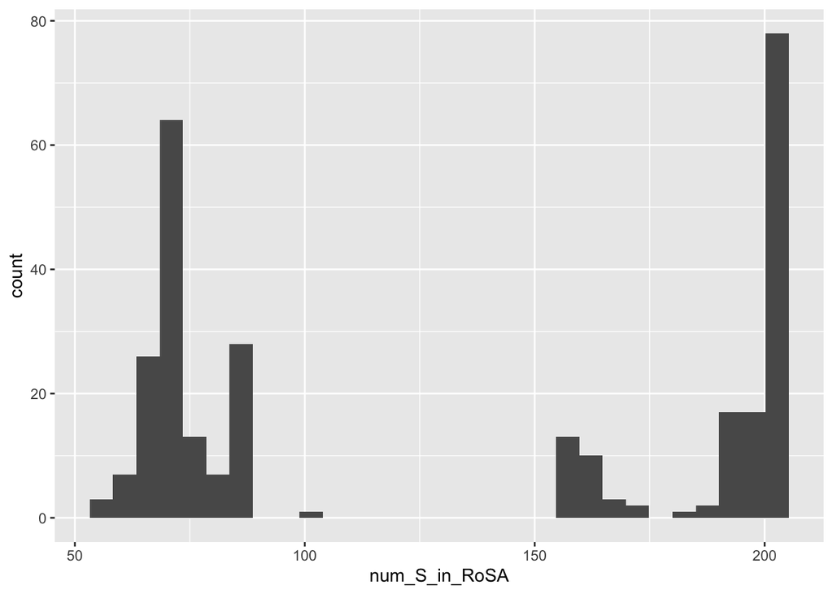

```r
big_haps3 %>%
  group_by(Indiv, haplo) %>%
  summarise(num_S_in_RoSA = num_S_in_RoSA[1]) %>%
  ggplot(aes(x = num_S_in_RoSA)) +
  geom_histogram()
```

So, we can easily call anything with more than 100 spring alleles part of the spring-run haplotype group.

```r
big_haps4 <- big_haps3 %>%
  mutate(haplo_group = ifelse(num_S_in_RoSA > 100, "early", "late"))
```

Now we can compute the frequencies of these different alleles when we break things up by different groups.

Here, just using the stated ecotype of each individual are the results we get:

```r
big_haps4 %>%
  group_by(POS, ecotype) %>%
  summarise(freq_of_S_allele = sum(alle2 == "S")) %>%
  spread(key = ecotype, value = freq_of_S_allele)
```

| POS | Fall | Late_Fall | Spring | Winter |
| --- | --- | --- | --- | --- |
| 12265346 | 7 | 0 | 105 | 30 |
| 12265891 | 7 | 0 | 106 | 30 |
| 12470211 | 57 | 14 | 102 | 22 |
| 12470298 | 113 | 28 | 106 | 31 |
| 12472352 | 100 | 21 | 106 | 32 |

And, we can see where that is going! Clearly the 7 copies in the Fall populations are due to heterozygotes, and that is also probably the case a couple springers.

Let’s do this again with the relative frequencies.

```r
big_haps4 %>%
  group_by(POS, ecotype) %>%
  summarise(freq_of_S_allele = mean(alle2 == "S")) %>%
  spread(key = ecotype, value = freq_of_S_allele)
```

| POS | Fall | Late_Fall | Spring | Winter |
| --- | --- | --- | --- | --- |
| 12265346 | 0.05737705 | 0.00000 | 0.9905660 | 0.93750 |
| 12265891 | 0.05737705 | 0.00000 | 1.0000000 | 0.93750 |
| 12470211 | 0.46721311 | 0.43750 | 0.9622642 | 0.68750 |
| 12470298 | 0.92622951 | 0.87500 | 1.0000000 | 0.96875 |
| 12472352 | 0.81967213 | 0.65625 | 1.0000000 | 1.00000 |

So, let’s break it out by haplotype group:

```r
big_haps4 %>%
  group_by(POS, haplo_group) %>%
  summarise(freq_of_S_allele = sum(alle2 == "S")) %>%
  spread(key = haplo_group, value = freq_of_S_allele)
```

| POS | early | late |
| --- | --- | --- |
| 12265346 | 142 | 0 |
| 12265891 | 143 | 0 |
| 12470211 | 125 | 70 |
| 12470298 | 142 | 136 |
| 12472352 | 143 | 116 |

OK, we need to know what the total number of haplotypes is in there too:

```r
big_haps4 %>%
  group_by(POS, haplo_group) %>%
  summarise(
    freq_of_S_allele = sum(alle2 == "S"),
    freq_of_F_allele = sum(alle2 != "S")
  )
```

| POS | haplo_group | freq_of_S_allele | freq_of_F_allele |
| --- | --- | --- | --- |
| 12265346 | early | 142 | 2 |
| 12265346 | late | 0 | 148 |
| 12265891 | early | 143 | 1 |
| 12265891 | late | 0 | 148 |
| 12470211 | early | 125 | 19 |
| 12470211 | late | 70 | 78 |
| 12470298 | early | 142 | 2 |
| 12470298 | late | 136 | 12 |
| 12472352 | early | 143 | 1 |
| 12472352 | late | 116 | 32 |

```r
big_haps4 %>%
  group_by(POS, haplo_group) %>%
  summarise(freq_of_S_allele = mean(alle2 == "S")) %>%
  spread(key = haplo_group, value = freq_of_S_allele)
```

| POS | early | late |
| --- | --- | --- |
| 12265346 | 0.9861111 | 0.0000000 |
| 12265891 | 0.9930556 | 0.0000000 |
| 12470211 | 0.8680556 | 0.4729730 |
| 12470298 | 0.9861111 | 0.9189189 |
| 12472352 | 0.9930556 | 0.7837838 |

## Codons in coho salmon

So, what remains now is to verify that the spring-associated alleles are the same as in coho. We use our aligned coho genome for that.

```bash
# pull out the bits from chinook:
samtools faidx genome/Otsh_v1.0_genomic.fna NC_037124.1:12265344-12265346
#>NC_037124.1:12265344-12265346
#CTT


# That corresponds to the codon AAG.  If the spring variant were in the
# reference genome then we'd get CTC.

# pull out the same bit from our coho alignment
samtools faidx stored_results/001/NC_037124.1_coho.fna.gz  NC_037124.1:12265344-12265346
#>NC_037124.1:12265344-12265346
#CTC


# there you have it!

# and now we do the same for the other non-synonymous position
samtools faidx genome/Otsh_v1.0_genomic.fna NC_037124.1:12265889-12265891
#>NC_037124.1:12265889-12265891
#GGA

# that, corresponds to the codon TCC.  So, the spring-associated
# form will be GGG.
samtools faidx stored_results/001/NC_037124.1_coho.fna.gz  NC_037124.1:12265889-12265891
#>NC_037124.1:12265889-12265891
#GGG

# Boom!
```

```
## >NC_037124.1:12265344-12265346
## CTT
## >NC_037124.1:12265344-12265346
## CTC
## >NC_037124.1:12265889-12265891
## GGA
## >NC_037124.1:12265889-12265891
## GGG
```

Now, let’s also check a final time on REF and ALT in the original VCF, to make sure that it all accords as it is supposed to here.

```bash
# Check the first position
bcftools view data/greb1l-ish-region.vcf.gz NC_037124.1:12265346 | awk '/^##/ {next} {print $1, $2, $3, $4, $5}'
#CHROM POS ID REF ALT
#NC_037124.1 12265346 . T C

# Yep, that is correct

# and the second
bcftools view data/greb1l-ish-region.vcf.gz NC_037124.1:12265891 | awk '/^##/ {next} {print $1, $2, $3, $4, $5}'
#CHROM POS ID REF ALT
#NC_037124.1 12265891 . A G

# also correct
```

```
## #CHROM POS ID REF ALT
## NC_037124.1 12265346 . T C
## #CHROM POS ID REF ALT
## NC_037124.1 12265891 . A G
```

OK! This all forms the basis for Table S1: “Two near-perfectly associated, non-synonymous variants in the GREB1L gene.”

# Running Time

Running the code and rendering this notebook required approximately this much time on a Mac laptop of middling speed:

```r
Sys.time() - start_time
```

```
## Time difference of 6.37954 mins
```

Citations